# Geographic Data Visualization in R

Andrew McCormack

2019-01-10

# Overview of workshop

In this workshop, you will learn how to visualize spatial data in R. Spatial data are widely available for many different political contexts, making them an excellent resource for communicating information that is geographic in nature. Despite their abundance as a data source, working with specialized shapefiles can be daunting to the uninitiated. The aim of this workshop is disentangle many of challenges of working with spatial data in R. We begin with the basics of importing and manipulating shapefiles. Next, we cover how to create beautiful visualizations with spatial data in the ggplot2 package. In the remainder of the workshop, participants will learn how generate interactive maps using the leaflet package.

## Getting started

```r
library(tidyverse)
library(leaflet)
library(sf)
library(sp)
library(maptools)
library(rgdal)
library(rmapshaper)
library(broom)
library(ggthemes)
```

# Shapefiles

## What is a shapefile?

To demonstrate how to work with Shapefiles in R, we will work with a Shapefile containing 2018 Provincial electoral divisions for Québec. I have obtained this Shapefile from [Élections Québec](https://www.electionsquebec.qc.ca/english/provincial/electoral-map/provincial-electoral-division-geometric.php) and included it in the supplementary materials for this workshop. The folder `quebec_prov_ridings` contains 5 different files:

```
## [1] "qc_ridings.CPG" "qc_ridings.dbf" "qc_ridings.prj" "qc_ridings.shp"
## [5] "qc_ridings.shx"
```

If this is your first time working with a Shapefile, you may be surprised to notice that there are several individual files named `qc_ridings`, each with a different file extension. Though its name suggests a single file, a shapefile is actually a group of files containing feature geometry and feature attribute data. While different data sources will provide different types of constituent files, three of these files are essential: `.shp`, `.shx`, and `.dbf`:

- `.shp`: the file that contains the geometry for all features
- `.shx`: indexes the geometry
- `.dbf`: contains feature attributes in tabular format

## How to load a shapefile into R

Because my working directory is set to the folder containing the `quebec_prov_ridings` folder, I simply type `quebec_prov_ridings`. If you are working from within the directory where the Shapefile is located, specify `dsn = "."`.

```r
rd <- readOGR(dsn = "quebec_prov_ridings",
              layer = "qc_ridings")
```

Now that we’ve imported the Shapefile into our environment, let’s see what we are working with:

```r
summary(rd)
```

```
## Object of class SpatialPolygonsDataFrame
## Coordinates:
##         min     max
## x  79569.03 1697055
## y 113908.06 2105873
## Is projected: TRUE
## proj4string :
## [+proj=lcc +lat_1=50 +lat_2=46 +lat_0=44 +lon_0=-70 +x_0=800000
## +y_0=0 +datum=NAD83 +units=m +no_defs +ellps=GRS80 +towgs84=0,0,0]
## Data attributes:
##      CO_CEP                   NM_CEP             NM_TRI_CEP
##  Min.   :104.0   Abitibi-Est     :  1   ABITIBIEST    :  1
##  1st Qu.:300.0   Abitibi-Ouest   :  1   ABITIBIOUEST  :  1
##  Median :476.0   Acadie          :  1   ACADIE        :  1
##  Mean   :491.1   Anjou-Louis-Riel:  1   ANJOULOUISRIEL:  1
##  3rd Qu.:702.0   Argenteuil      :  1   ARGENTEUIL    :  1
##  Max.   :938.0   Arthabaska      :  1   ARTHABASKA    :  1
##                  (Other)         :119   (Other)       :119
```

```
        min     max
x  79569.03 1697055
y 113908.06 2105873
```

The next few lines give us the projection information:

```
Is projected: TRUE
```

```
+proj=lcc +lat_1=50 +lat_2=46 +lat_0=44 +lon_0=-70 +x_0=800000 +y_0=0 +datum=NAD83 +units=m +no_defs +ellps=GRS80 +towgs84=0,0,0
```

As you may know, the Earth is round. In order to plot maps in a two-dimensional space, spherical coordinates (such as latitude and longitude) must be transformed to planar coordinates (x and y). This is a [complicated topic](https://courses.washington.edu/gis250/lessons/projection/) subject to [much debate](https://xkcd.com/977/). For the purposes of this workshop, we will accepts Élections Québec’s projection.

The last few lines of the ouput from `summary(rd)` gives us a summary of each column in the attributes table. This is the dataframe associated with the `qc_ridings` Shapefile. Because they don’t have very intuitive names, here is a description of each variable:

- `CO_CEP`: the electoral district code. This variable will be very useful when it comes to merging in other sources of data.
- `NM_CEP`: the official name of the electoral district
- `NM_TRI_CEP`: electoral district names transformed into non-accented capital letters, removing all characters that are not letters

Let’s take a look at this Shapefile with the `plot()` function:

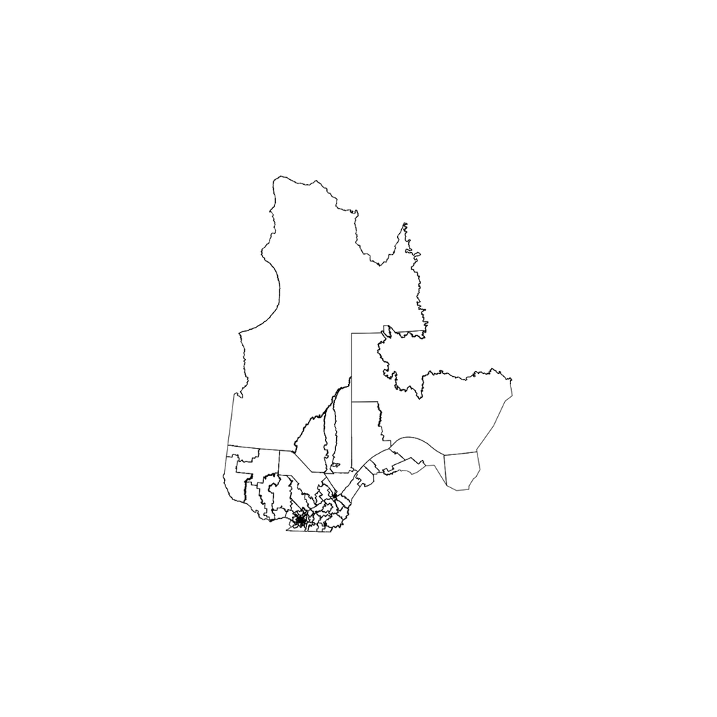

```r
plot(rd)
```

While the `plot()` function is a good method for making sure that the Shapefile is looking and working as it should, below we will construct our plots using the `ggplot2` package, and not `plot()` (which is part of base R graphics).

## Simplifying shapefiles

Often, Shapefiles will be very large and it will take your computer a while to load them into R and even longer to manipulate and plot them. When creating static maps, we often don’t need the level of precision that large Shapefiles provide. For this reason, it is often desirable to simplify our Shapefile after importing it into R.

To do this, we can use the `ms_simplify()` function from the `rmapshaper` package. The `ms_simplify()` function will samples points from the polygons in `rd` to reduce it’s size while preserving the polygons’ (ridings’) shapes. While this function has a number arguments, we will focus on the essentials: `input`, `keep`, and `keep_shapes`:

- The `input` argument is where we specify the Shapefile we want to simplify
- The `keep` argument is the proportion of points from the original Shapefile we want to retain. We can get away with a surprising amount of reduction here without substantially altering the appearance of the map. You will notice that we specify `keep = 0.05`, which means we will keep only 5 percent of the original points.
- The `keep_shapes` argument, when `TRUE`, prevents small polygons from disappearing at high levels of simplifications. Because we don’t want to lose any of our ridings in the simplification process, we specify `keep_shapes = TRUE`

```r
rd_simple <- ms_simplify(input = rd,
                         keep = 0.05,
                         keep_shapes = TRUE)
```

```r
# How does size of simplified Shapefile compare to original Shapefile?
(object.size(rd_simple)/object.size(rd))[1]
```

```
## [1] 0.08054286
```

After simplifying with `ms_simplify()`, the Shapefile is now only 8 percent of its original size. This will make visualizing these data much more efficient!

Let’s plot this simplified Shapefile to see how it compares to our original plot:

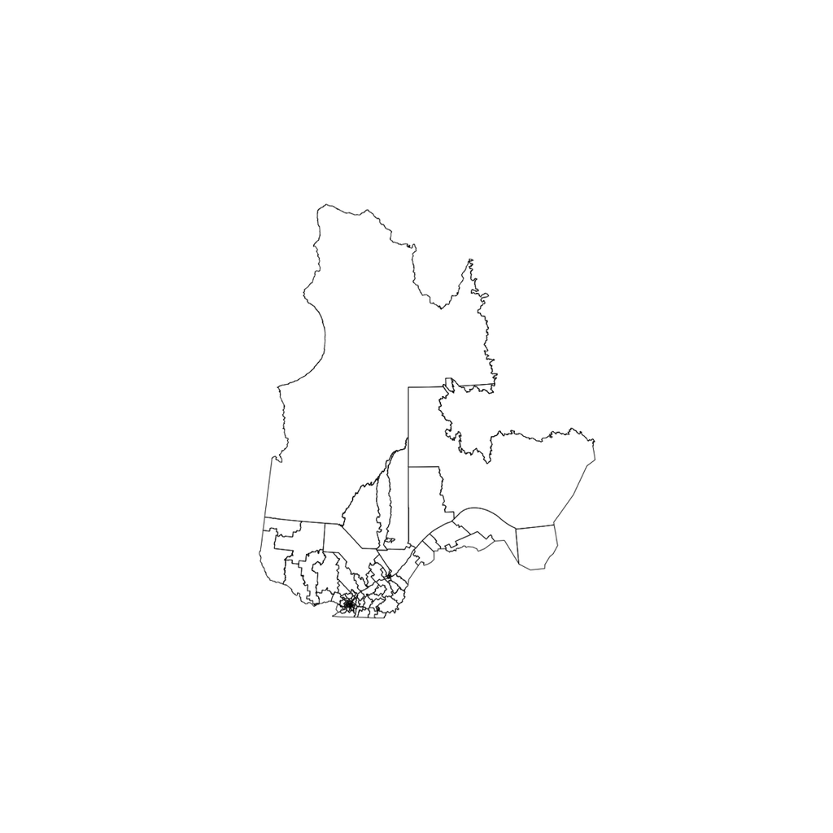

```r
plot(rd_simple)
```

As you can see, the map looks essentially the same. We were able to greatly reduce the size of the original Shapefile while not sacrificing a lot of detail. You may also have noticed that this plot loaded much faster than the plot we created with the original shapefile.

## Converting a `SpatialPolygonsDataFrame` object into to data frame

While the generic `plot()` function can use `SpatialPolygonsDataFrame` objects directly, `ggplot2` cannot. Therefore we need to extract them as a data frame.

The `tidy()` function from the `broom` package comes in handy here. This function converts a variety of different R objects into data frame objects..] Most imporantly for us, `tidy()` can coerce a `SpatialPolygonsDataFrame` into a data frame. To do so, we input the object we want converted, which is our `SpatialPolygonsDataFrame` object, `rd_simple` into the `tidy()` function. We also need to specify a `region` from the attribute data of `rd_simple` so that we know which coordinates go with which provincial ridings:

More specifically, `tidy()` convert a number of different model outputs into *tibbles*, which are a type of data frame. This distinction isn’t important for our purposes, [but you can read more here](https://cran.r-project.org/web/packages/tibble/vignettes/tibble.html)

```r
rd_df <- broom::tidy(x = rd_simple, region = "NM_CEP")

# Examine the first few rows of the data frame
head(rd_df)
```

```
##       long      lat order  hole piece         group          id
## 1 387411.5 442553.4     1 FALSE     1 Abitibi-Est.1 Abitibi-Est
## 2 383820.0 442794.0     2 FALSE     1 Abitibi-Est.1 Abitibi-Est
## 3 372141.0 443647.0     3 FALSE     1 Abitibi-Est.1 Abitibi-Est
## 4 371718.0 442975.0     4 FALSE     1 Abitibi-Est.1 Abitibi-Est
## 5 371056.0 442660.0     5 FALSE     1 Abitibi-Est.1 Abitibi-Est
## 6 370695.0 441870.1     6 FALSE     1 Abitibi-Est.1 Abitibi-Est
```

- `long`: longitude, a measure of east-west position
- `lat`: latitude, a measure of north-south position
- `group`: an identifier that is unique for each region (in this case, Quebec provincial riding)
- `id`: the names for each group (in this case, `NM_CEP`)

Unfortunately, in the process of converting `rd_simple` into a data frame, we lost all the attribute data (aside from the `id` column, which was originally `NM_CEP`) associated with the provincial ridings. To remedy this, we can merge the attribute data from the `SpatialPolygonsDataFrame` (`rd_simple`) with the data frame we just created (`rd_df`) using `dplyr`’s merge functions. By default `dplyr`’s merge functions look for a common variable, or common variables, between the two data frames we want to merge. In our case, although we have two common variables, they have different names. For this reason, we need to explicity specify the variables we want to merge on:

For more information on `dplyr`’s merge functions, I suggest [this cheatsheat](https://stat545.com/bit001_dplyr-cheatsheet.html) and/or [this guide](https://rpubs.com/williamsurles/293454)

```r
rd_df <- right_join(rd_df,
          rd_simple@data,
          by = c("id" = "NM_CEP"))
```

Now all of the variables from the original Shapefile have returned. In this case, the original Shapefile only had three variables, all of which were identifiers for the provincial riding. Other Shapefiles may contain a greater amount of attribute data, making it important to merge these two data frames.

## Plotting spatial data in `ggplot2`

To create a map with the `rd_df` data frame we just created, the following aesthetic mappings are required: `x = long` (longitude), `y = lat` (latitude), and `group = group` (this tells `geom_polygon()` how to group observations—in this case, provinces).

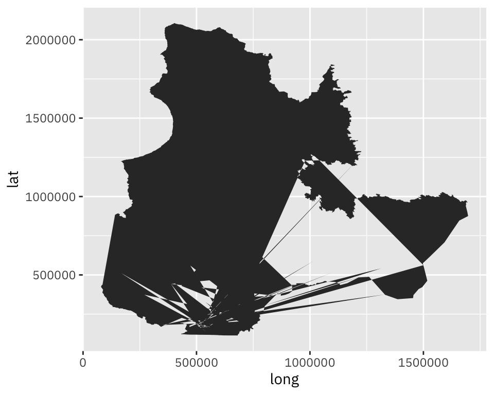

```r
ggplot(rd_df, aes(long, lat)) +
  geom_polygon()
```

This map does not look very good. What did I miss here? Yes, you are right: we need a grouping variable so that `geom_polygon()` knows that each riding is its own polygon.

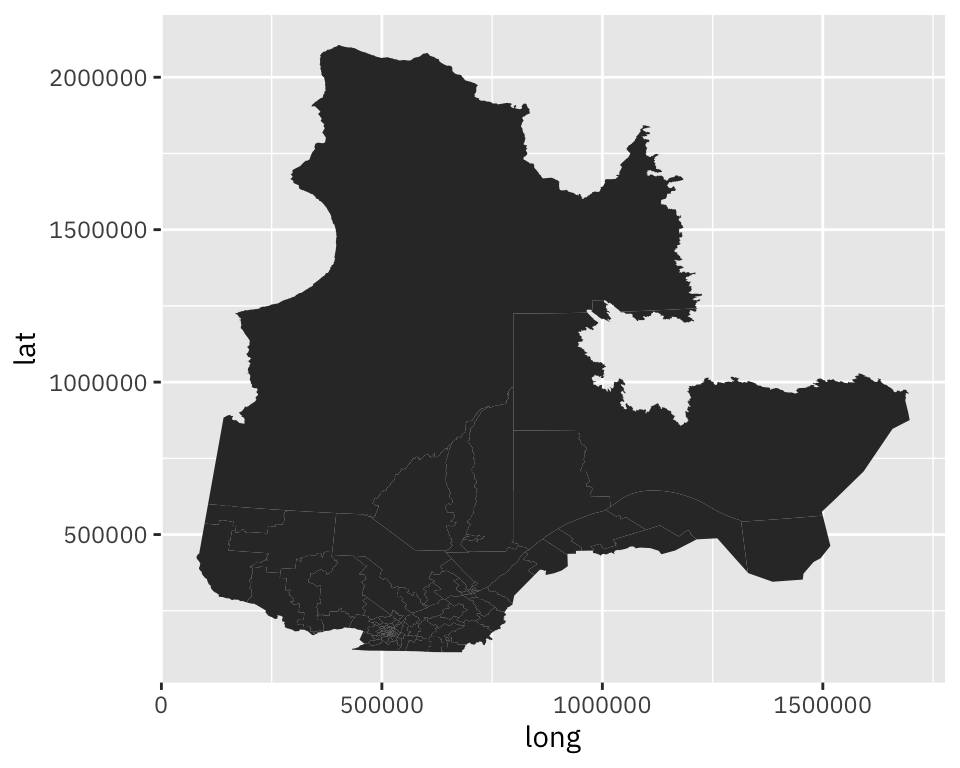

```r
ggplot(rd_df, aes(x = long,
                  y = lat,
                  group = group)) +
  geom_polygon()
```

This map looks better, but there are still a number of issues. First, it looks like `ggplot` alters the shape of the map based on the width and length of the plot. While this may work for other types of plots, it does not work for maps. To get an accurate map of Quebec, we need to specify `coord_fixed()`. This fixes the relationship between the axes such that one unit on the x-axis (longitude) is the same length as one unit on the y-axis (latitude):

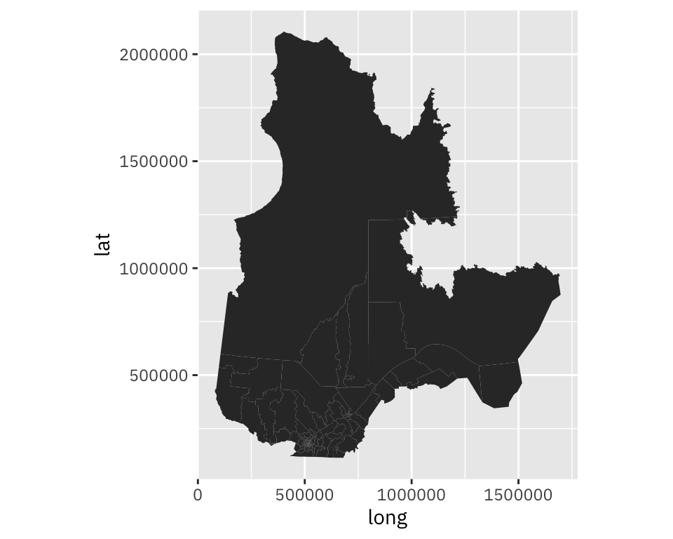

```r
ggplot(rd_df, aes(x = long,
                  y = lat,
                  group = group)) +
  geom_polygon() +
  coord_fixed()
```

You will also notice that the axis text has no substantive significance. You can remove it, along with the axis ticks and background grid using a theme of your choice. For a simplistic presentation, I suggest `theme_void()`.

Two other `ggplot` theme options that are useful for maps are `theme_map()` from the `hrbrthemes` package and `theme_map()` from the `ggthemes` package.

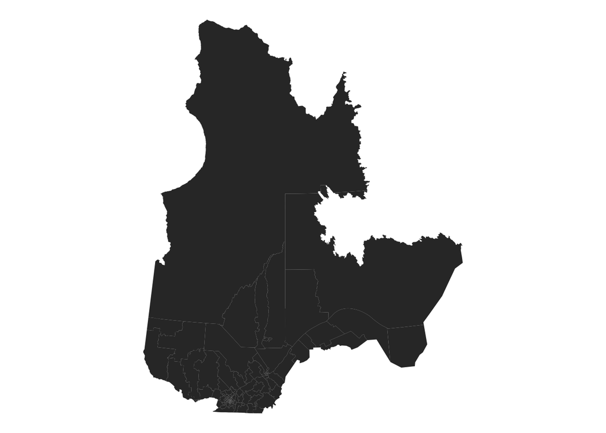

```r
ggplot(rd_df, aes(x = long,
                  y = lat,
                  group = group)) +
  geom_polygon() +
  coord_fixed() +
  theme_void()
```

# Incorporating data into the map

So far, we have just plotted raw coordinates, which is not very exciting. Our map will be far more informative if we incorporate some Quebec provincial riding-level statistics. To do so, we need to find and then merge riding-level data with our geographic coordinates (`rd_df`). I have included some example data with this workshop, which can be loaded with the `read.csv()` function below:

```r
qc_val <- read.csv("https://raw.githubusercontent.com/mccormackandrew/geoviz_workshop/master/r_data/qc_val.csv",
                   stringsAsFactors = FALSE)
head(qc_val)
```

```
##   X mother_tongue_english mother_tongue_french immigrant_share
## 1 1           0.046706449            0.3284370     0.011732544
## 2 2           0.002227378            0.9896984     0.007777778
## 3 3           0.003328262            0.9926778     0.008637874
## 4 4           0.010247315            0.9864026     0.008742633
## 5 5           0.008043876            0.9874771     0.011208311
## 6 6           0.007473310            0.9775801     0.018254320
##   aboriginal_share vismin_population low_income_share unemployment_rate
## 1       0.66735019       0.011618635            0.037              13.0
## 2       0.10657407       0.006574074            0.057              12.1
## 3       0.03644647       0.007782840            0.049               9.5
## 4       0.04686118       0.005206798            0.041               8.7
## 5       0.04064522       0.011937306            0.085               8.8
## 6       0.04191405       0.019672131            0.097               8.3
##                    region    riding_name riding_code
## 1          Nord-du-Québec         Ungava         938
## 2 Saguenay—Lac-Saint-Jean       Roberval         930
## 3 Saguenay—Lac-Saint-Jean Lac-Saint-Jean         926
## 4 Saguenay—Lac-Saint-Jean          Dubuc         914
## 5 Saguenay—Lac-Saint-Jean      Jonquière         922
## 6 Saguenay—Lac-Saint-Jean     Chicoutimi         918
```

These data come from [Quebec’s chief returning officer (DGEQ)](https://www.electionsquebec.qc.ca/english/provincial/electoral-map/socioeconomic-files.php) and are based on the 2016 census. For the purpose of this workshop, I narrowed the data down to a number of relevant socio-demographic indicators.

Let’s merge these data with our riding coordinates data.

```r
rd_df <- left_join(rd_df, qc_val, c("id" = "riding_name"))
head(rd_df)
```

```
##       long      lat order  hole piece            group             id
## 1 516813.0 182778.1  2263 FALSE     1 Bourassa-Sauvé.1 Bourassa-Sauvé
## 2 516184.9 181996.2  2264 FALSE     1 Bourassa-Sauvé.1 Bourassa-Sauvé
## 3 515150.2 182931.0  2265 FALSE     1 Bourassa-Sauvé.1 Bourassa-Sauvé
## 4 515815.5 184227.9  2266 FALSE     1 Bourassa-Sauvé.1 Bourassa-Sauvé
## 5 515501.8 184610.4  2267 FALSE     1 Bourassa-Sauvé.1 Bourassa-Sauvé
## 6 516101.0 185963.0  2268 FALSE     1 Bourassa-Sauvé.1 Bourassa-Sauvé
##   CO_CEP    NM_TRI_CEP  X mother_tongue_english mother_tongue_french
## 1    360 BOURASSASAUVE 43            0.04399775            0.4993674
## 2    360 BOURASSASAUVE 43            0.04399775            0.4993674
## 3    360 BOURASSASAUVE 43            0.04399775            0.4993674
## 4    360 BOURASSASAUVE 43            0.04399775            0.4993674
## 5    360 BOURASSASAUVE 43            0.04399775            0.4993674
## 6    360 BOURASSASAUVE 43            0.04399775            0.4993674
##   immigrant_share aboriginal_share vismin_population low_income_share
## 1       0.4220611      0.006919034         0.4994345            0.221
## 2       0.4220611      0.006919034         0.4994345            0.221
## 3       0.4220611      0.006919034         0.4994345            0.221
## 4       0.4220611      0.006919034         0.4994345            0.221
## 5       0.4220611      0.006919034         0.4994345            0.221
## 6       0.4220611      0.006919034         0.4994345            0.221
##   unemployment_rate   region riding_code
## 1              12.5 Montréal         360
## 2              12.5 Montréal         360
## 3              12.5 Montréal         360
## 4              12.5 Montréal         360
## 5              12.5 Montréal         360
## 6              12.5 Montréal         360
```

Now that we have the variables we need, let’s create a more informative plot. To do this, we need to specify our variable of interest as a `fill` aesthetic inside ggplot. The `fill` aesthetic will colour the provincial ridings according to variable we feed it. I will feed it the `mother_tongue_english` variable, which is the proportion of the total population whose first language is English.

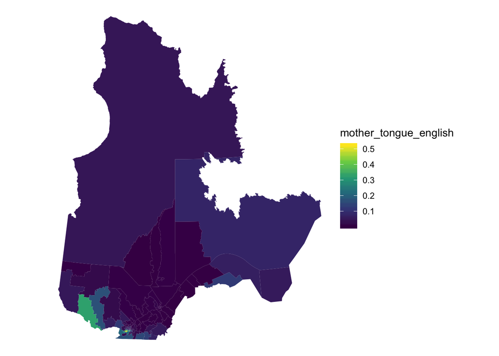

```r
ggplot(rd_df, aes(x = long,
                  y = lat,
                  group = group,
                  fill = mother_tongue_english)) +
  geom_polygon() +
  coord_fixed() +
  theme_void() +
  scale_fill_viridis_c()
```

Although this plots exactly what we had intended—mother tongue by provincial riding in Quebec—this map is not a very useful visual aid for understanding the proportion of Anglophones in Quebec. It overemphasizes larger geographical units by assigning them a stronger visual weight. Because it is not land area itself we are interested in, this leads to a distorted impression of the data.

There are a number of solutions for this. First, we can use an alternative mapping technique, such as a hexagonal grid map. Though we don’t cover hexagonal grid maps in this workshop, they can be created for Quebec provincial ridings using the `mapcan` package.

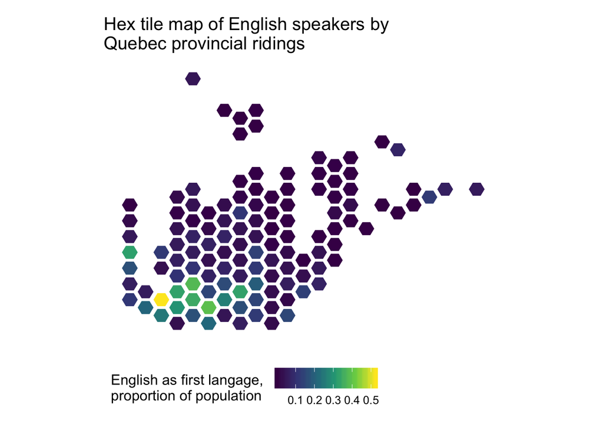

For an overview of how `mapcan` works, consult [this guide](https://www.dropbox.com/s/unibo5h481lg8my/mapcan_workshop.pdf?dl=0).

Another solution is to create a map that focuses on a smaller region of Quebec, like Montréal. To do this, we can subset `rd_df` to include only ridings from Montréal within `ggplot`:

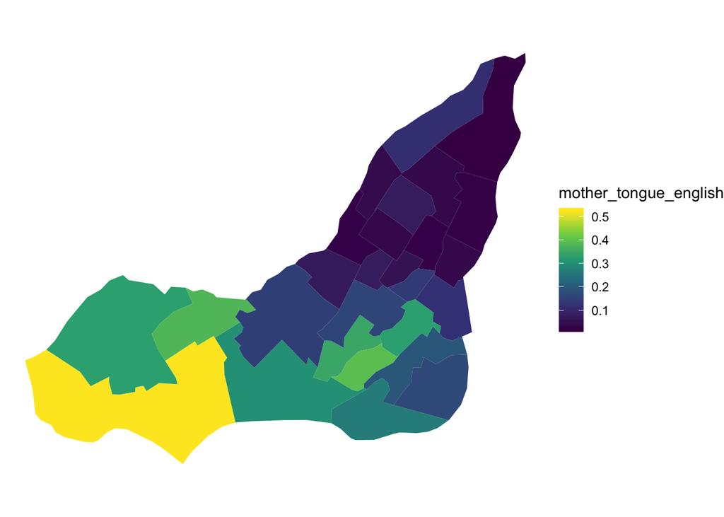

```r
ggplot(rd_df[rd_df$region == "Montréal", ],
       aes(long, lat, group = group, fill = mother_tongue_english)) +
  geom_polygon() +
  coord_fixed() +
  theme_void() +
  scale_fill_viridis_c()
```

By focusing on Montréal, we reveal some of the heterogeneity we missed out on with the full map of Quebec.

Thus far, we have learned how to work with Shapefiles to create static maps in `ggplot2`.

## Creating interactive maps in R

There are a number of packages in R that offer powerful tools for creating interactive maps. We will focus on one of the most powerful and user-friendly of these packages—`leaflet`. Leaflet is a Javascript library for interactive maps which can be used in R with the `leaflet` package.

```r
# Fix projection
rd_leaf <- spTransform(rd_simple, CRS("+init=epsg:4326"))

leaflet() %>%
  addPolygons(data = rd_leaf) %>%
  addTiles()
```

[interactive chart not shown]